# Randomise plates for repeat pairs

Stefano Giulieri

22/02/2021

Here we randomise a new set of plates: they will include all genetic pairs with significant PI changes (as selected by Romain).

Some questions to clarify:

- keep pairs on the same plate?
- confirm controls and their position

```r
knitr::opts_chunk$set(echo = TRUE)
knitr::opts_knit$set(root.dir = here::here())
msg <- glue::glue("My directory is {here::here()}")
message(msg)
```

```
## My directory is /Users/giulieris/OneDrive - The University of Melbourne/R/VANANZ_phenotypes_github
```

```r
library(tidyverse)
library(tidygraph)
library(ggraph)
rm(list = ls())

source("Functions/all_functions.R")
```

# List of strains

```r
significant_pairs_PI <- read_csv("Genetic_pairs_analysis_Oct_2020/processed_data/monophyletic_clusters/genetic_pairs_significant_PI_change.csv") %>%
  mutate(phenotype = "PI")
glimpse(significant_pairs_PI)
```

```
## Rows: 31
## Columns: 4
## $ non_directional_pair_id <chr> "BPH2925-BPH2926", "BPH3652-BPH3694", "BPH367…
## $ iso1                    <chr> "BPH2925", "BPH3652", "BPH3757", "BPH2923", "…
## $ iso2                    <chr> "BPH2926", "BPH3694", "BPH3672", "BPH2924", "…
## $ phenotype               <chr> "PI", "PI", "PI", "PI", "PI", "PI", "PI", "PI…
```

```r
significant_pairs_GC <- read_csv("Genetic_pairs_analysis_Oct_2020/processed_data/monophyletic_clusters/genetic_pairs_significant_GC_change.csv") %>%
  mutate(non_directional_pair_id = str_c(iso1, iso2, sep = "-"),
         phenotype = "GC")
glimpse(significant_pairs_GC)
```

```
## Rows: 22
## Columns: 4
## $ iso1                    <chr> "BPH2965", "BPH2866", "BPH2737", "BPH2702", "…
## $ iso2                    <chr> "BPH2966", "BPH2867", "BPH2738", "BPH2816", "…
## $ non_directional_pair_id <chr> "BPH2965-BPH2966", "BPH2866-BPH2867", "BPH273…
## $ phenotype               <chr> "GC", "GC", "GC", "GC", "GC", "GC", "GC", "GC…
```

```r
# intersection between the two datasets?
intersect_strains <- intersect(c(significant_pairs_PI$iso1, significant_pairs_PI$iso2),
          c(significant_pairs_GC$iso1, significant_pairs_GC$iso2)) %>%
  sort()
length(intersect_strains)
```

```
## [1] 14
```

```r
intersect_pairs <- intersect(significant_pairs_PI$non_directional_pair_id,
                             significant_pairs_GC$non_directional_pair_id) %>%
  sort()
length(intersect_pairs)
```

```
## [1] 2
```

```r
# union
union_strains <- union(c(significant_pairs_PI$iso1, significant_pairs_PI$iso2),
          c(significant_pairs_GC$iso1, significant_pairs_GC$iso2)) %>%
  sort()
length(union_strains)
```

```
## [1] 92
```

```r
union_pairs <- union(significant_pairs_PI$non_directional_pair_id,
                             significant_pairs_GC$non_directional_pair_id) %>%
  sort()
length(union_pairs)
```

```
## [1] 51
```

```r
significant_pairs <- significant_pairs_PI %>%
  full_join(significant_pairs_GC) %>%
  group_by(non_directional_pair_id, iso1, iso2) %>%
  summarise(phenotype = str_c(phenotype,
                              collapse = " & "))
```

We have 92 unique strains for 51 pairs (union of the two datasets). Fourteen strains are shared but only two pairs are both PI and GC.

Graph representation. We use `tidygraph::centrality_betwenness()` to highlight nodes (strains) with more than one connection (= strains in more than one contrasting pair)

```r
pairs_net <- as_tbl_graph(significant_pairs %>% ungroup %>% select(from = iso1, to = iso2, phenotype, non_directional_pair_id ))

pairs_net
```

```
## # A tbl_graph: 92 nodes and 51 edges
## #
## # A directed simple graph with 42 components
## #
## # Node Data: 92 x 1 (active)
##   name
##   <chr>
## 1 BPH2700
## 2 BPH2702
## 3 BPH2704
## 4 BPH2710
## 5 BPH3382
## 6 BPH2720
## # … with 86 more rows
## #
## # Edge Data: 51 x 4
##    from    to phenotype non_directional_pair_id
##   <int> <int> <chr>     <chr>
## 1     1    49 GC        BPH2700-BPH2876
## 2     2    50 GC        BPH2702-BPH2816
## 3     3    51 PI        BPH2704-BPH2705
## # … with 48 more rows
```

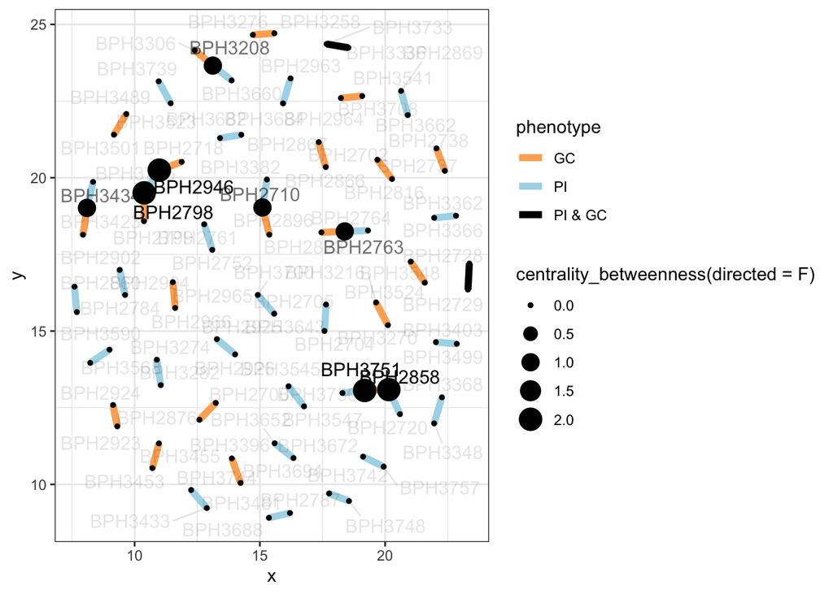

```r
ggraph(pairs_net, layout = "nicely") +
  geom_edge_link(aes(colour = phenotype), edge_width = 2) +
  geom_node_point(aes(size = centrality_betweenness(directed = F)),
                  colour = "black") +
  geom_node_text(aes(label = name, alpha = centrality_betweenness(directed = F)), repel = T, size = 4) +
  scale_alpha_continuous(guide = F) +
  scale_edge_color_manual(values = c("#fdae61", "#abd9e9", "black")) +
  theme_bw()
```

We now use `tidygraph::group_components()` to group nodes (strains) and edges (pairs) according to whether they are connected or not. This will allow us to create groups of connected strains that will have to be on the same plate.

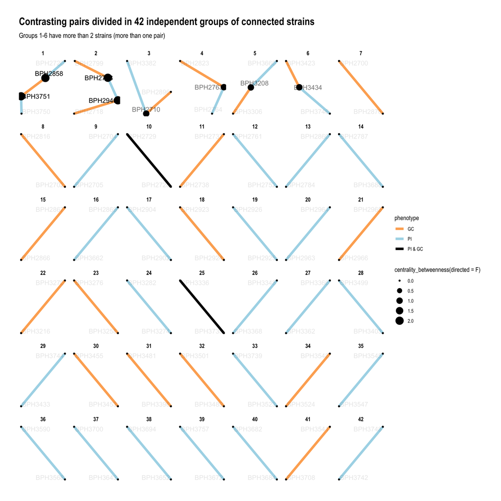

```r
pairs_net %>%
  activate(nodes) %>%
  mutate(g = group_components()) %>%
  ggraph(layout = "nicely") +
  geom_edge_link(aes(colour = phenotype), edge_width = 2) +
  geom_node_point(aes(size = centrality_betweenness(directed = F))) +
  geom_node_text(aes(label = name, alpha = centrality_betweenness(directed = F)), repel = T, size = 4) +
  facet_nodes(~as.factor(g), scales = "free") +
  scale_alpha_continuous(guide = F) +
  scale_edge_color_manual(values = c("#fdae61", "#abd9e9", "black")) +
  labs(title = "Contrasting pairs divided in 42 independent groups of connected strains",
       subtitle = "Groups 1-6 have more than 2 strains (more than one pair)") +
  theme_graph()
```

```r
df_graph_groups <- pairs_net %>%
  activate(nodes) %>%
  mutate(g = group_components()) %>%
  as_tibble() %>%
  arrange(g)
glimpse(df_graph_groups)
```

```
## Rows: 92
## Columns: 2
## $ name <chr> "BPH2720", "BPH3751", "BPH2858", "BPH3750", "BPH2798", "BPH2799"…
## $ g    <int> 1, 1, 1, 1, 2, 2, 2, 2, 3, 3, 3, 4, 4, 4, 5, 5, 5, 6, 6, 6, 7, 7…
```

```r
controls <- c("JE2", "TOX-4", "Non infected")
n_replicates_controls <- c(3,3,3)
n_isolates_plate <- (96 - sum(n_replicates_controls))/3

df <- df_graph_groups %>%
  transmute(sample_id = name,
         pair_id = as.factor(g)) %>%
  arrange(pair_id)

plates_vector <- c() # empty vector with plate numbers.
# The for loop will generate three variables
# x (plate number), j (number of strains on the plate including the current one),
# k (number of strains on the plate if all samples from the same patient are added)
x <- 1
j <- 1
for (i in 1:nrow(df)){
  if (i > 1){ # need to start from the second row to avoid NA
    episode <- df$pair_id[i]
    previous <- df$pair_id[i -1]

    if (episode != previous ){ # compute k only for the first strain if multiple strains per episode
      n_isolates_episode <- length(which(df$pair_id == df$pair_id[i]))
      k <- j + n_isolates_episode - 1 # substract 1 because first isolates already included in j
      # if the number of strains (including expected multiple same-patient isolates) exceeds the maximum number, start a new plate
      if (j > n_isolates_plate | k > n_isolates_plate){
        j <- 1
        x <- x + 1
      }
    } else {
    if (j > n_isolates_plate){
      j <- 1
      x <- x + 1
    }
  }
  }
  plates_vector[i] <- x
  j <- j + 1
}
df_strains_plate <- df %>%
  mutate(plate = plates_vector) %>%
  mutate(plate = str_c("GP", plate + 7))
glimpse(df_strains_plate)
```

```
## Rows: 92
## Columns: 3
## $ sample_id <chr> "BPH2720", "BPH3751", "BPH2858", "BPH3750", "BPH2798", "BPH…
## $ pair_id   <fct> 1, 1, 1, 1, 2, 2, 2, 2, 3, 3, 3, 4, 4, 4, 5, 5, 5, 6, 6, 6,…
## $ plate     <chr> "GP8", "GP8", "GP8", "GP8", "GP8", "GP8", "GP8", "GP8", "GP…
```

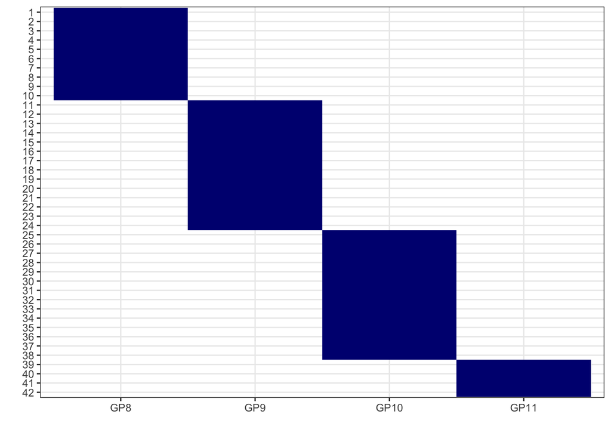

```r
# Quick check that the same-pair strains are on the same plate
df_strains_plate %>%
  ggplot(aes(x = fct_rev(pair_id),
             y = fct_relevel(plate, c("GP8", "GP9")))) +
  geom_tile(fill = "navy") +
  coord_flip() +
  labs(x = "", y = "") +
  theme_bw()
```

```r
rm(df, significant_pairs)
rm(i, j, k, n_isolates_plate, plates_vector, previous)
```

Now we can plan the plates

```r
dir <- "plate_info/well_info/"
dir.create(dir)
well_info <- lapply(unique(df_strains_plate$plate), function(x){
  df <- df_strains_plate %>%
    filter(plate == x)
  well_info <- plate_planner(
    isolates = df$sample_id,
  randomise = TRUE,
  fixed = NULL,
  controls = controls,
  n_replicates_controls = n_replicates_controls
) %>%
    mutate(plate_number = x)

  write_csv(well_info,
            str_c(dir, "well_info_plate", x, ".csv"))

  return(well_info)
}) %>%
  bind_rows()
```

```
## # A tibble: 96 x 2
##    sample_id replicate
##    <chr>     <chr>
##  1 BPH3423   2
##  2 BPH2799   3
##  3 BPH2700   1
##  4 BPH2798   1
##  5 JE2       3
##  6 BPH2823   1
##  7 BPH2710   2
##  8 BPH3751   1
##  9 BPH3208   2
## 10 BPH2876   3
## # … with 86 more rows
```

```
## # A tibble: 96 x 2
##    sample_id replicate
##    <chr>     <chr>
##  1 BPH3270   2
##  2 BPH2923   3
##  3 BPH2737   1
##  4 BPH2904   1
##  5 JE2       3
##  6 BPH2925   1
##  7 BPH2784   2
##  8 BPH3688   1
##  9 BPH2966   2
## 10 BPH2963   3
## # … with 86 more rows
```

```
## # A tibble: 96 x 2
##    sample_id replicate
##    <chr>     <chr>
##  1 BPH3652   2
##  2 BPH3499   3
##  3 BPH3336   1
##  4 BPH3489   1
##  5 JE2       3
##  6 BPH3523   1
##  7 BPH3368   2
##  8 BPH3744   1
##  9 BPH3568   2
## 10 BPH3545   3
## # … with 86 more rows
```

```
## # A tibble: 96 x 2
##    sample_id    replicate
##    <chr>        <chr>
##  1 Non infected 2
##  2 Non infected 3
##  3 BPH3541      1
##  4 Non infected 1
##  5 Non infected 3
##  6 Non infected 1
##  7 BPH3708      2
##  8 Non infected 1
##  9 Non infected 2
## 10 Non infected 3
## # … with 86 more rows
```

And map them on the 96-well plate

```r
dir <- "plate_info/plate_maps/"

plate_info <- lapply(unique(df_strains_plate$plate), function(x){
  df <- well_info %>%
    filter(plate_number == x)
  plate_info <- plate_mapper(df)
  return(plate_info)
})
names(plate_info) <- str_c(
  "plate_",
  unique(df_strains_plate$plate))
for (i in plate_info) print(knitr::kable(i, format = "pipe"))
```

```
##
##
## |row |01      |02           |03           |04      |05      |06           |07           |08           |09           |10      |11      |12      |
## |:---|:-------|:------------|:------------|:-------|:-------|:------------|:------------|:------------|:------------|:-------|:-------|:-------|
## |A   |BPH3423 |BPH2799      |BPH2700      |BPH2798 |JE2     |BPH2823      |BPH2710      |BPH3751      |BPH3208      |BPH2876 |JE2     |BPH2720 |
## |B   |BPH2896 |BPH3660      |BPH2704      |BPH3660 |BPH3750 |BPH2799      |BPH3750      |TOX-4        |BPH2823      |BPH2764 |BPH2798 |BPH3434 |
## |C   |BPH2816 |BPH2799      |BPH2720      |BPH2763 |BPH3750 |BPH3746      |BPH2816      |BPH3423      |BPH2729      |BPH2946 |BPH2946 |BPH2702 |
## |D   |BPH3208 |Non infected |TOX-4        |BPH3434 |BPH3306 |BPH2728      |BPH2764      |Non infected |BPH2700      |BPH2823 |BPH2718 |BPH2728 |
## |E   |BPH2896 |BPH3434      |Non infected |BPH3382 |BPH3306 |BPH2728      |BPH3382      |BPH3208      |Non infected |BPH2705 |BPH2718 |BPH2798 |
## |F   |BPH2710 |BPH3382      |BPH3751      |TOX-4   |BPH2858 |Non infected |Non infected |BPH2763      |BPH3746      |BPH2876 |BPH2705 |BPH2718 |
## |G   |BPH2858 |BPH3423      |JE2          |BPH2946 |BPH2858 |BPH2704      |BPH2763      |BPH3746      |BPH2816      |BPH3751 |BPH2705 |BPH2876 |
## |H   |BPH2729 |BPH2700      |BPH2896      |BPH3306 |BPH2764 |BPH2704      |BPH2710      |BPH2729      |BPH2720      |BPH2702 |BPH3660 |BPH2702 |
##
##
## |row |01      |02           |03           |04      |05      |06           |07           |08           |09           |10      |11      |12      |
## |:---|:-------|:------------|:------------|:-------|:-------|:------------|:------------|:------------|:------------|:-------|:-------|:-------|
## |A   |BPH3270 |BPH2923      |BPH2737      |BPH2904 |JE2     |BPH2925      |BPH2784      |BPH3688      |BPH2966      |BPH2963 |JE2     |BPH2860 |
## |B   |BPH2964 |BPH3276      |BPH2752      |BPH3276 |BPH3662 |BPH2923      |BPH3662      |TOX-4        |BPH2925      |BPH2902 |BPH2904 |BPH3274 |
## |C   |BPH2924 |BPH2923      |BPH2860      |BPH2869 |BPH3662 |BPH3282      |BPH2924      |BPH3270      |BPH2867      |BPH2965 |BPH2965 |BPH2738 |
## |D   |BPH2966 |Non infected |TOX-4        |BPH3274 |BPH3216 |BPH2866      |BPH2902      |Non infected |BPH2737      |BPH2925 |BPH2787 |BPH2866 |
## |E   |BPH2964 |BPH3274      |Non infected |BPH3258 |BPH3216 |BPH2866      |BPH3258      |BPH2966      |Non infected |BPH2761 |BPH2787 |BPH2904 |
## |F   |BPH2784 |BPH3258      |BPH3688      |TOX-4   |BPH2926 |Non infected |Non infected |BPH2869      |BPH3282      |BPH2963 |BPH2761 |BPH2787 |
## |G   |BPH2926 |BPH3270      |JE2          |BPH2965 |BPH2926 |BPH2752      |BPH2869      |BPH3282      |BPH2924      |BPH3688 |BPH2761 |BPH2963 |
## |H   |BPH2867 |BPH2737      |BPH2964      |BPH3216 |BPH2902 |BPH2752      |BPH2784      |BPH2867      |BPH2860      |BPH2738 |BPH3276 |BPH2738 |
##
##
## |row |01      |02           |03           |04      |05      |06           |07           |08           |09           |10      |11      |12      |
## |:---|:-------|:------------|:------------|:-------|:-------|:------------|:------------|:------------|:------------|:-------|:-------|:-------|
## |A   |BPH3652 |BPH3499      |BPH3336      |BPH3489 |JE2     |BPH3523      |BPH3368      |BPH3744      |BPH3568      |BPH3545 |JE2     |BPH3403 |
## |B   |BPH3547 |BPH3700      |BPH3362      |BPH3700 |BPH3739 |BPH3499      |BPH3739      |TOX-4        |BPH3523      |BPH3481 |BPH3489 |BPH3694 |
## |C   |BPH3501 |BPH3499      |BPH3403      |BPH3455 |BPH3739 |BPH3733      |BPH3501      |BPH3652      |BPH3453      |BPH3548 |BPH3548 |BPH3348 |
## |D   |BPH3568 |Non infected |TOX-4        |BPH3694 |BPH3590 |BPH3433      |BPH3481      |Non infected |BPH3336      |BPH3523 |BPH3396 |BPH3433 |
```

[output cut: 16 more lines]

```r
purrr::walk(names(plate_info), function(x){
  df <- plate_info[[x]]
  file <- str_c(
    dir, "/",
    x,
    ".csv"
  )
  write_csv(df, file)
})
```